# 概要

# PID制御によるドローン高さ制御

普通の二次系とかモータ制御系はきっとググれば分かる． 前々から疑問だった，減衰項のない単振動の制御を考えてみる． 例としてドローンのZ制御を扱う.

ちなみに調べたところによると，市販ドローンは速度制御マイナーループを作り，位置制御メジャーループを構成しているようだ．

## 対象システム

要件

- 入力：z方向推力f [N]
- 出力：z方向位置z [m]
- 初期条件：z=z0 離陸済みの状態（空中からスタート）
- 制約：常に初期位置から位置偏差3m以内で制御すること

システムパラメータ

- 重量m=3[kg]
- 最大推力=6.2[kgf]

制御対象モデリング $$f-mg = f' =m\ddot{z} $$ ここで$f'$は重力と釣り合う推力

伝達関数 $$G(s)=\frac{1}{ms^2}$$

伝達関数のボード線図から次のことが分かる

- 直流入力に対してゲイン->∞なので，入力fが釣り合い推力から少しでもずれると発散する
- 常に位相=-180degなので，位相余裕を確保するために位相進め要素必須

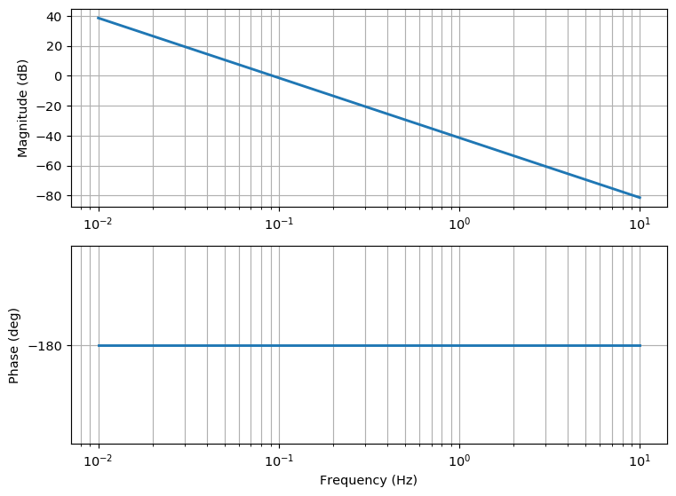

```python
def comp_bode(Cs,name):
    sysp_ol = series(G,Cs)
    sysp_cl = feedback(sysp_ol)
    omega = list( linspace(2*pi*0.01 , 2*pi*10,10000) )

    figure()
    ax1,ax2,line1,line2 = draw_bode2(G,omega)
    line1.set_label("G(s)")
    ax1,ax2,line1,line2 = draw_bode2(Cs,omega)
    line1.set_label("C(s)")
    ax1,ax2,line1,line2 = draw_bode2(sysp_cl,omega)
    line1.set_label("CL")
    ax1,ax2,line1,line2 = draw_bode2(sysp_ol,omega)
    line1.set_label("OL")
    gcf().legend()
    gcf().suptitle(name)
    return Cs,sysp_ol,sysp_cl

m = 3
G = tf([1],[m,0,0])
figure()
ax1,ax2,line1,line2 = draw_bode(G)
line1.set_label("G(s)")
```

コントローラ要件

-> 偏差3mのときに最大推力を出力するようなコントローラにする つまり，コントローラゲインについて以下が成り立つようにしたい． $$|C(s)|_{max} < 20log \left( \frac{f'_{max} g}{\Delta z} \right)$$ ※g:重力加速度

```python
ratio_Cmax = 3.2*9.8/3
gain_Cmax = 20*log10(ratio_Cmax)
print("max gain of controller = {0:.4f} N/m = {1:.4f} db".format(ratio_Cmax,gain_Cmax))
```

```
max gain of controller = 10.4533 N/m = 20.3851 db
```

## P制御

いったんP制御だけで試してみる． PID制御において，DとI要素の接点周波数の間のゲイン（ボード線図の＼＿／の底の部分）はKpによって決まるので，まずはKpを最大コントローラゲインにして設計していく.

ボード線図を見ると閉ループに0.3Hz程度の共振点が現れている． また，CL伝達関数を見ても減衰項のない二次系になっているから，単振動を続けると思われる．

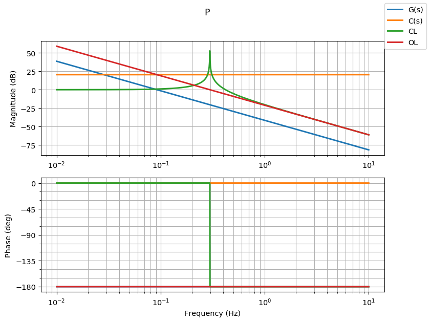

```python
# P control
def tfp(Kp):
    return tf([Kp],[1])
Kp = ratio_Cmax
Cp = tfp(Kp)
C,ol,cl = comp_bode(Cp,"P")
```

```python
print("Kp={0:.4f}".format(Kp))
print("C(s)=")
C
```

```
Kp=10.4533
C(s)=
```

$$\frac{10.45}{1}$$

```python
print("OL(s)=")
ol
```

```
OL(s)=
```

$$\frac{10.45}{3 s^2}$$

```python
print("CL(s)=")
cl
```

```
CL(s)=
```

$$\frac{10.45}{3 s^2 + 10.45}$$

実際にステップ入力の結果を見てみる． (Xcosを利用)

[figure not shown]

応答波形から以下が分かる

- 周期3.5sec=0.29Hzで振動する．
  - CL周波数特性のゲインピーク部分に相当する．
- 入力推力は偏差と同相(比例制御だから)
  - 偏差=0になったときに推力=0にしても，既に速度を持っているから通り過ぎてしまう．
  - 偏差=0になる前に減速に転じる必要がある
  - 例えばz=0.5(約1.5sec)の時点で加速から減速に転じたい
  - つまり偏差に対して推力の位相を時間軸左側に進めたい
- 推力位相を進めるためには位相進め要素である微分器を入れる

## PD制御

微分コントローラの接点周波数はいくつにするか？ -> CL特性の位相が落ち込むところに効いてほしいから，0.29Hz近辺を狙ってみる．

CL伝達関数の形は減衰ありの二次系になっている． このことからD要素はダンパとして働くことが分かる． 未知のシステムに対してはD要素を入れておけば事故が減って良さそう．

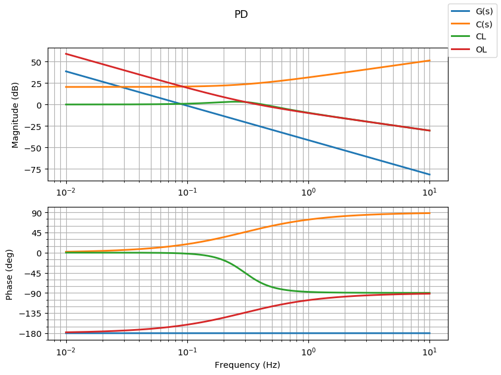

```python
# PD control
def tfd(fcorner):
    Td = 1/(2*pi*fcorner)
    return tf([Td,1],[1]),Td

fpeek = 0.29
Cd,Td = tfd(fpeek)
C,ol,cl=comp_bode(series(Cp,Cd),"PD")
```

```python
print("Td={0:.4f} -> Kd={1:.4f}".format(Td,Td*Kp))
print("C(s)=")
C
```

```
Td=0.5488 -> Kd=5.7369
C(s)=
```

$$\frac{5.737 s + 10.45}{1}$$

```python
print("OL(s)=")
ol
```

```
OL(s)=
```

$$\frac{5.737 s + 10.45}{3 s^2}$$

```python
print("CL(s)=")
cl
```

```
CL(s)=
```

$$\frac{5.737 s + 10.45}{3 s^2 + 5.737 s + 10.45}$$

ステップ応答は以下のようになった

[figure not shown]

ステップ入力を見ると，無事に目標値に収束している． また，偏差と推力の関係を見ても，狙い通り推力の位相が進んでいる．

一方で，ステップ入力時の出力が無限大に発散してしまっている． そこで，微分の代わりに不完全微分を使うことにする

## 不完全微分PD制御

微分コントローラの折点周波数をそのままに推力の抑制を考える． 設計パラメータは，推力抑制の最大値をいくつにするか？である．

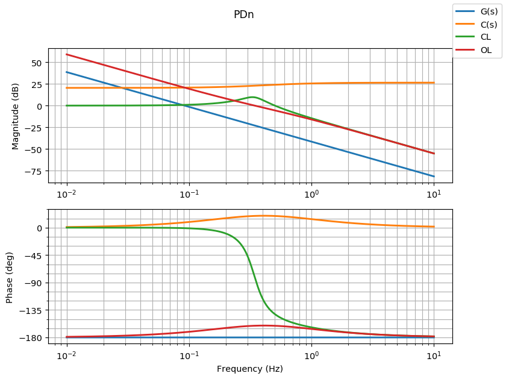

```python
    # PDn PDimcomplete control
    def tfdn(fcorner,ratio):
        # ratio : 20log(1) at low freq, 20log(ratio) at high freq
        Td = 1/(2*pi*fcorner)
        N = ratio
        return tf([Td,1],[Td/N,1]),Td,N
    outratio = 2
    Cdn,_,_ = tfdn(fpeek,outratio)
    C,ol,cl = comp_bode(series(Cp,Cdn),"PDn")
```

```python
print("C(s)=")
C
```

```
C(s)=
```

$$\frac{5.737 s + 10.45}{0.2744 s + 1}$$

```python
print("OL(s)=")
ol
```

```
OL(s)=
```

$$\frac{5.737 s + 10.45}{0.8232 s^3 + 3 s^2}$$

```python
print("CL(s)=")
cl
```

```
CL(s)=
```

$$\frac{5.737 s + 10.45}{0.8232 s^3 + 3 s^2 + 5.737 s + 10.45}$$

ステップ入力の結果を示す．

[figure not shown]

## PID制御

せっかくなので積分コントローラも使うことにする．

```python
ol
```

$$\frac{5.737 s + 10.45}{0.8232 s^3 + 3 s^2}$$

今の制御系の一巡伝達関数は上記の形． 以下のように変形できるので，積分器を2つ持っていることが分かる(2型) $$\frac{1}{s^2} \frac{b_1s+b_0}{a_1s+a_0}$$ なので，偏差の二階微分要素に対しては定常偏差が生じる つまり，加速度・推力外乱に対して定常偏差が生じる． 例として-5Nの直流外乱を付与したシミュレーションを示す．

[figure not shown]

コントローラ設計値は積分時間=接点周波数の位置

- 積分入れると位相が遅れるから，0.3Hzよりも十分低域に設定してゼロクロスに影響しないようにしたい
- 狙いたいのは直流外乱だから，低域でOK
- 接点周波数を高周波にすれば定常偏差消えるまでの時間が早くなるはずだけどどのくらいにしたら？

いったんは0.05Hzで設計してみる．

```
Ti=3.1831 -> Ki=3.2840
```

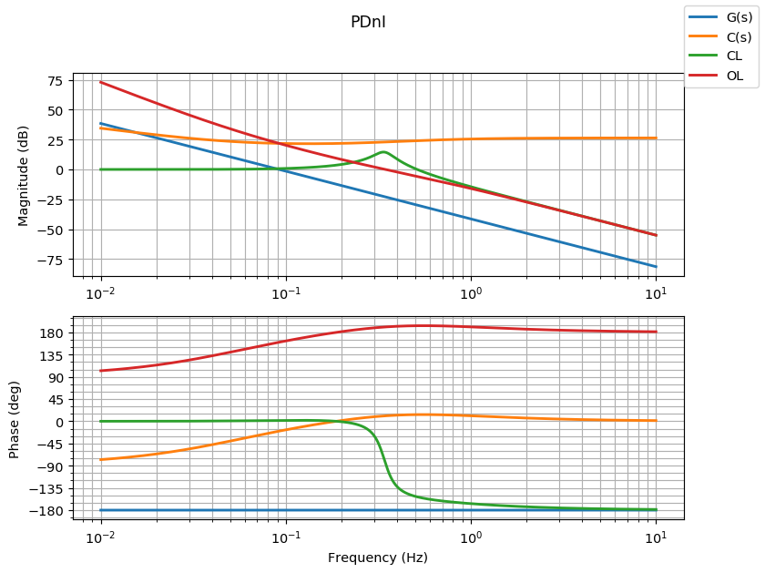

```python
def tfi(fcorner):
    Ti = 1/(2*pi*fcorner)
    return tf([Ti,1],[Ti,0]),Ti
fi = 0.05
Ci,Ti = tfi(fi)
print("Ti={0:.4f} -> Ki={1:.4f}".format(Ti,Kp/Ti))
C,ol,cl = comp_bode(series(Cp,Cdn,Ci),"PDnI")
```

```python
print("C(s)=")
C
```

```
C(s)=
```

$$\frac{18.26 s^2 + 39.01 s + 10.45}{0.8735 s^2 + 3.183 s}$$

```python
print("OL(s)=")
ol
```

```
OL(s)=
```

$$\frac{18.26 s^2 + 39.01 s + 10.45}{2.62 s^4 + 9.549 s^3}$$

```python
print("CL(s)=")
cl
```

```
CL(s)=
```

$$\frac{18.26 s^2 + 39.01 s + 10.45}{2.62 s^4 + 9.549 s^3 + 18.26 s^2 + 39.01 s + 10.45}$$

ステップ入力結果は以下のようになった

[figure not shown]

## ノッチフィルタ

ここまでのPID制御ではステップ入力に対して振動しながら収束している． 現状の応答性をそのままに振動抑制を考える．

PID制御系のCL特性を見ると，0.34Hzにて15dbのピークを持っている． また，ゲインピークの裾は0.34Hzを中心に±0.2Hz程度の幅を持っている.

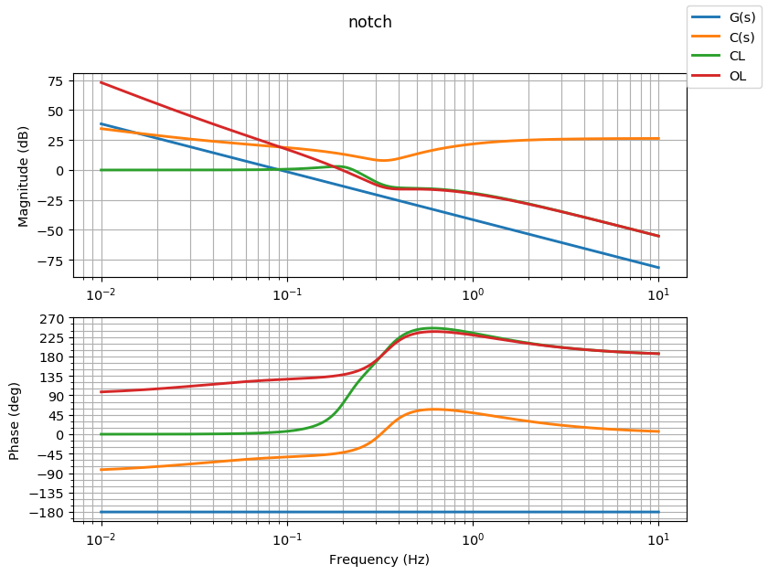

```python
    # notch
    def tfnotch(gain_db,delta_freq,freq):
        # gain_db : gain = gain_db at freq
        # delta_freq : gain = 0 at freq+-delta_freq
        R= 10**(gain_db/20)
        z=(freq + delta_freq) / freq
        w=2*pi*freq
        return tf([1,2*R*z*w,w**2],[1,2*z*w,w**2]),R,z,w

    fpeek = 0.34
    gain_db = -15
    delta_f = 0.2
    Cnc,R,z,w = tfnotch(gain_db,delta_f,fpeek)
    _ = comp_bode(series(Cp,Cdn,Ci,Cnc),"notch")
```

```python
print("R={0:.4f},z={1:.4f},w={2:.4f}".format(R,z,w))
print("C(s)=")
C
```

```
R=0.1778,z=1.5882,w=2.1363
C(s)=
```

$$\frac{18.26 s^2 + 39.01 s + 10.45}{0.8735 s^2 + 3.183 s}$$

```python
print("OL(s)=")
ol
```

```
OL(s)=
```

$$\frac{18.26 s^2 + 39.01 s + 10.45}{2.62 s^4 + 9.549 s^3}$$

```python
print("CL(s)=")
cl
```

```
CL(s)=
```

$$\frac{18.26 s^2 + 39.01 s + 10.45}{2.62 s^4 + 9.549 s^3 + 18.26 s^2 + 39.01 s + 10.45}$$

ステップ入力は以下のようになった

[figure not shown]

0.34Hz振動は発生していないが，0.2Hz程度の不安定振動が生じた．

コントローラ位相が0.2sec=15deg遅れている．

なんでだろう？

# より高度な制御

## フィードフォワード制御

フィードバック制御では一つのコントローラによって系の安定性と応答性を両立しなくてはいけない． 安定性と応答性を分けて考えられるようにするのがフィードフォワード制御．

ここで$Gr(s)$は目標値への追従性を表す伝達関数，$Gd(s)$は外乱への応答=安定性を表す伝達関数になっている． この式からも，コントローラ$C(s)$の設計が安定性と応答性の両方に効く事がわかる．

入力$r$と外乱$d$の閉ループ伝達関数は以下の式になる． $$Gr(s) = \frac{Y}{R} = \frac{P(C+Cf)}{1+PC}$$ $$Gd(s) = \frac{Y}{D} = \frac{P}{1+PC}$$

この構成ならコントローラ$C(s)$で安定性設計を行い，$Cf(s)$で応答性設計が独立してできるようになっている． 特に，$Cf(s) = P(s)^{-1}$であれば，フィードフォワードコントローラへの入力(目標値) = 出力値になるため，外乱の無い系に対して完全な制御(偏差なし，遅れなし)を実現することができる．

一般的な自然界のシステムは遅れ系であることから，$P(s)$はプロパー(伝達関数の分母の次数のほうが大きい)になる．そのため$Cf(s) = P(s)^{-1}$を構成しようとすると$Cf(s)$は非プロパーなコントローラになる． 連続系における議論では非プロパーなコントローラは実現できない． なぜなら，非プロパー分子の次数が大きい=微分器が含まれる=ステップ入力に対して無限大を出力するようなコントローラを作らなきゃいけないから． そこで$Cf(s)$がプロパーになるような補償器$F(s)$を$C(s),Cf(s)$にカスケード結合することでフィードフォワード制御を実現する工夫が必要．

参考書には難しいことが書いてあるが，現代はデジタル制御ばっかりなので，離散系で差分器を使えば$Cf(s)=P(s)^{-1}$なるコントローラが近似できてしまうからあまり気にしなくて良さそう．

## 外乱オブザーバ

制御対象$P(s)$のモデル$Pn(s)$を持っているとき，モデルによる予測と，実際の観測を用いて入力を補正する方法．

## カスケード制御

モータ制御でよく使われている． 電流制御コントローラ，速度制御コントローラ，位置制御コントローラと複数のコントローラをカスケード結合して対象を制御する方法．

設計目標

- インナーループの高帯域化 = 外乱やモデル化誤差の補償

メリット

- アウターループから見ると既知のモデル通りの動きに見えて設計が簡単になる．
- インナーループ内の外乱の影響をアウターループが受けにくい = アウターループを高帯域化できる

## アンチワインドアップ

制御入力値は現実的には飽和を起こす． 飽和した場合，基本的に応答性は劣化する．

応答性劣化の要因の一つは積分コントローラの出力（らしい） 原理はさておき，制御量飽和時には積分コントローラへの偏差入力をゼロにして偏差が溜まらないようにしておくと良いらしい．

# その他細かい話

## 周波数伝達関数とはなんぞや

$G(s)$を$G(j\omega)$にしたものはどういう経緯で出てきたのか？ 一般のLTI(Linear Time Invariant : 時不変)システムは以下の式．

$$ a_n \frac{d^ny}{dt^n} + \cdots + a_1\frac{dy}{dt} + a_0 = x \\ \iff Y(s) (a_n s^n + \cdots + a_1s + a_0) = X(s) \\ \iff Y(s) H(s) = X(s)$$

ここで$H(s)$は伝達関数$G(s)$の逆数

このシステムの周波数特性を知りたいというのは言い換えれば， 入力$x=Asin(\omega t)=Ae^{j\omega t}$のときのLTIシステム方程式の特殊解(=定常解)が知りたいということ． 特特解を$y_p$とすると，その解の形は以下のようになる． $$y_p = \alpha sin(\omega t+\beta) = \alpha e^{j \omega t + \beta}$$ LTI方程式に代入すると以下のようになる． $$ \alpha [ a_n (j\omega)^n + \cdots + a_1(j\omega) + a_0] e^{j\omega t + \beta} = Ae^{j\omega t} \\ \iff \alpha ( H(j\omega) ) e^{j\omega t + \beta} = Ae^{j\omega t} $$

※指数関数の微分 $$\frac{d}{dt} e^{j\omega t} = \frac{d}{dt}(j\omega t)e^{j\omega t} = j\omega e^{j\omega t}$$

ここでたまたま$H(j\omega)$の形が出てくる．つまり以下のような対応関係になっているということ． $$ \begin{eqnarray} \mathcal{L} \left[ \frac{d^n}{dt^n}y \right] &=& s^n Y \\ \frac{d^n}{dt^n} y &=& (j \omega)^n y \ \ \ where \ y= e^{j\omega t} \end{eqnarray} $$ なので，物理的な意味というよりも数学的な意味で$s \rightarrow j\omega$にすると便利みたい．

実際にゲインの計算までやってみる．システム方程式を更に解き進めると以下のようになる．

$$ \begin{eqnarray} \alpha ( H(j\omega) ) e^{j\omega t + \beta} &=& Ae^{j\omega t} \\ \iff \alpha (Xj+Y)e^{\beta}e^{j\omega t} &=& Ae^{j\omega t} \\ \iff \alpha [ (Xj+Y)(cos\beta + j sin\beta )]e^{j\omega t} &=& Ae^{j\omega t} \\ \iff \alpha [(Ycos\beta -X sin\beta ) + (Xcos\beta + Ysin\beta )j ]e^{j\omega t} &=& Ae^{j\omega t} \\ \iff \alpha \sqrt{X^2+Y^2} [cos(\beta-\phi)+jsin(\beta-\phi)]e^{j\omega t} &=& Ae^{j\omega t} \\ \iff \alpha \sqrt{X^2+Y^2} e^{j\omega t +(\beta-\phi)} &=& Ae^{j\omega t} \\ \end{eqnarray} $$

ここで以下の変数変換を用いた $$ X=a_1\omega-a_3\omega^3+a_5\omega^5-\cdots \\ Y=a_0-a_2\omega^2+a_4\omega^4-\cdots \\ \phi=arctan\frac{Y}{-X}=-arctan\frac{Y}{X}=arctan\frac{X}{Y} $$

よって $$\alpha = \frac{1}{A}\sqrt{X^2+Y^2} \\ \beta=arctan\frac{Y}{X} $$

一般に伝達関数でよく使われるのは$G(s)=1/H(s)$だから，$\alpha,\beta$が$G(j\omega)$を使って表せないか考える．

$$G(j\omega)=\frac{1}{Xj+Y}=\frac{Y}{X^2+Y^2}+\frac{X}{X^2+Y^2}j$$

だから，以下の式が成り立つ． $$\alpha = \frac{1}{A}\sqrt{Re[G(j\omega)]^2+Im[G(j\omega)]^2} \\ \beta = arctan\frac{Im[G(j \omega)]}{Re[G(j\omega)]} $$

したがって，ゲインと位相遅れは周波数伝達関数$G(j\omega)$を使って表すことができる．

## モータ回路方程式

LRC直列回路と等価としてモデリング

$$ \begin{eqnarray} v(t) &=& L \frac{di}{dt} + R i(t) + \frac{1}{C} \int_0^t i(t) dt \\ &=& L \frac{di}{dt} + R i(t) + e(t) \end{eqnarray} $$

ここで，コンデンサにおける電圧降下$e$は逆起電力と呼ばれる．（なぜC成分が逆起になるのかは調査したが理由不明） ラプラス変換すると以下のようになる $$ v(s) = (sL + R) i(s) + e(s) $$

## 電気-機械接続部の方程式

逆起はモータ回転速度に比例する(逆起電力定数$K_e$) $$ e(t) = K_e \frac{d\theta}{dt}$$ $$ \begin{eqnarray} e(s) &=& sK_e \theta(s) \\ &=& K_e \omega(s) \end{eqnarray} $$

モータトルクは電流に比例する(トルク定数$K_t$) $$ \tau(t) = K_t i(t)$$ $$ \tau(s) = K_t i(s)$$

## 式整理

$$ \begin{eqnarray} v(s) &=& (sL + R) i(s) + K_e \omega(s) \\ \iff i(s) &=& \frac{1}{sL+R}(v(s)-K_e\omega(s)) \\ &=& \frac{1}{sL+R}v_e(s) \end{eqnarray} $$

ただし実電圧を$v_e(s)$と置いた．

ブロック線図を書くと以下のようになる

[figure not shown]